# Conductivity as a Chloride-Discharge Proxy: Temporal Structure, Calibration, and Sampling-Frequency Design

Overarching reference for the Steamboat Creek continuous-conductivity / chloride sampling-frequency workflow

Published

September 25, 2026

## 1 Purpose and scope

This notebook is the **living scientific reference** for the continuous-conductivity and chloride-sampling-frequency workstream at Steamboat Hills — it documents *why* each analysis is done, *what* the math is, and *where* the code that implements it lives, and it is intended to stay the entry point for this line of work as more data and methods (new logger deployments, real paired Cl samples, refined models) accumulate. It complements, but does not replace, the individual R scripts in `scripts/analysis/sampling_frequency/`, which remain the executable source of truth; this document narrates and runs representative pieces of them so the reasoning and the code stay in sync.

Sections below run in dependency order:

1. Scientific motivation (why continuous conductivity, why chloride, why sampling frequency matters at all).
2. Instrumentation and site roles, with the provenance of a metadata correction that affects everything downstream.
3. Raw EC $\rightarrow$ temperature-compensated specific conductance, and the current state of field-calibration.
4. Temporal structure of specific conductance alone (this section requires no chloride data and is fully populated today).
5. The conductivity $\rightarrow$ chloride predictive-model framework (currently demonstrated on synthetic data pending temporal overlap with real samples).
6. Monte Carlo sampling-frequency design (same caveat).
7. Turning an error curve into an actionable sampling recommendation.
8. Current status, known gaps, and a running changelog.

**Warning**

As of this writing, each conductivity logger has only a few weeks of continuous record (deployed 2026-07-15), and the only chloride/isotope field samples collected so far (2026-05-01) **predate that deployment by roughly 2.5 months**. Sections 5–7 therefore run against synthetic self-test data, clearly labeled as such. Section 4 (temporal structure of conductivity alone) is real and current. Re-run this notebook once chloride samples exist that overlap the logger record.

## 2 Scientific motivation

Steamboat Hills is a geothermal outflow system in which chloride behaves approximately conservatively (non-reactive, non-volatile) in the shallow outflow plume, so the classic approach — used by Michael Sorey in prior studies of this system — is to treat **chloride discharge**, i.e. the mass flux

$$\Phi_{Cl} = \int_{t_0}^{t_1} C_{Cl}(t)\, Q(t)\, dt$$

(concentration $C_{Cl}$ in mg/L $\equiv$ g/m$^3$, discharge $Q$ in m$^3$/s, so $\Phi_{Cl}$ has units of grams over the interval $[t_0, t_1]$), as a tracer for the total geothermal outflow reaching the surface stream network. A change in $\Phi_{Cl}$ following the Lower Sinter Terrace eruption is direct evidence of a change in the underlying hydrothermal discharge, independent of dilution effects that would otherwise obscure a pure-concentration or pure-discharge signal.

Two practical problems follow directly from that framing:

- **Chloride analyses are expensive and infrequent** (lab turnaround, sampling effort), so $C_{Cl}(t)$ is only ever known at a sparse set of times.
- **Specific conductance is cheap, continuous, and correlates with dissolved ion content** (conductivity loggers record every 5 minutes), so it is a natural *proxy* for $C_{Cl}(t)$ between chemistry samples — provided the conductance-to-chloride relationship is characterized and its stability over time is checked.

This notebook’s methodological goal is therefore not just “does conductivity track chloride” but the sharper, decision-relevant question the thesis poses: **what is the coarsest chemistry (chloride) sampling interval that still lets us reconstruct $\Phi_{Cl}$, or $C_{Cl}(t)$, within an error the PI considers acceptable?** Sections 5–7 build the machinery to answer that quantitatively rather than by convention (e.g. “monthly because that’s typical”).

## 3 Instrumentation, site roles, and data provenance

Two HOBO/Onset “Full Range” EC loggers were deployed 2026-07-15 in Steamboat Creek to support this question:

| Location code | Role | Serial | Rationale |
| --- | --- | --- | --- |
| `SBRR` | `upstream_control` | 22575724 | Co-located with the USGS gauge near Rhodes Road; represents background/upstream water quality, upstream of the dominant geothermal inflow. |
| `SBGG` | `downstream` | 22575725 | Downstream of the outflow zone; expected to carry the geothermal Cl/EC signature. |

**NoteProvenance note: role/serial correction (2026-09-05)**

This correction matters for every downstream step in this document: any model, calibration, or figure that joins on `location_id`/`role` inherits the fix automatically (nothing in the modeling code hard-codes which physical serial is upstream — see the calibration check in the next section), but any *prior* interpretation of “SBRR” vs. “SBGG” behavior made before this date should be re-read with the roles reversed.

The `Conductivity_Loggers` table (below) is the single source of truth for this mapping; everything else in this document resolves location and role through it rather than hard-coding a serial number or coordinate.

```r
library(DBI)
library(RSQLite)
library(dplyr)
library(tidyr)
library(ggplot2)
library(lubridate)

# All chunks in this notebook execute with the working directory pinned to
# the project root, not to notebooks/. This matters because several sourced
# scripts (e.g. 02_specific_conductance.R) themselves source() other helper
# scripts using paths written relative to the project root -- the same
# assumption run_pipeline.R makes -- so pinning root.dir here keeps every
# path below identical to how these scripts are invoked from the pipeline.
knitr::opts_knit$set(root.dir = normalizePath(file.path(getwd(), "..")))
```

```r
db_path <- file.path("database", "geochem_operational.sqlite")
if (!file.exists(db_path)) db_path <- file.path("database", "geochem_demo.sqlite")

con <- dbConnect(SQLite(), db_path, flags = SQLITE_RO)

dbGetQuery(con, "
  SELECT cl.logger_id, cl.location_id, cl.role, cl.serial_number, l.external_station_code
  FROM Conductivity_Loggers cl
  LEFT JOIN Locations l ON cl.location_id = l.location_id
")
```

```
  logger_id location_id             role serial_number external_station_code
1         1           1       downstream      22575725                  SBGG
2         2          78 upstream_control      22575724                  SBRR
```

## 4 From raw EC to specific conductance: temperature compensation and calibration

Raw electrical conductivity ($EC_{raw}$) is temperature-dependent, so it is converted to **specific conductance at 25$^\circ$C** ($SC_{25}$) before any comparison across time or between the two loggers. The linear temperature-compensation model (USGS Techniques and Methods 1-D3) is:

$$SC_{25} = \frac{EC_{raw}}{1 + \beta\,(T - 25)}$$

with reference temperature $\theta = 25^\circ C$ and compensation coefficient $\beta$ (USGS default $\beta = 0.0191\ ^\circ C^{-1}$). This is implemented at ingest time in `scripts/ingest/helpers/compute_specific_conductance.R`:

```r
source(file.path("scripts", "ingest", "helpers", "compute_specific_conductance.R"))

# Reproduce the ingest-time formula directly, so the math and the code
# shown here are provably the same function used to populate sc_25c.
compute_specific_conductance
```

```
function (ec_raw, temperature_c, coefficient = 0.0191, theta = 25)
{
    ec_raw <- suppressWarnings(as.numeric(ec_raw))
    temperature_c <- suppressWarnings(as.numeric(temperature_c))
    denom <- 1 + coefficient * (temperature_c - theta)
    sc25 <- ec_raw/denom
    sc25[!is.finite(sc25)] <- NA_real_
    sc25
}
```

Because $\beta$ is an empirical property of the local water chemistry (ionic composition affects how conductivity responds to temperature), it should be periodically re-estimated against paired field conductivity checks rather than assumed to equal the USGS default indefinitely. `02_specific_conductance.R` does this by fitting

$$EC_{field,i} = \frac{EC_{raw,i}}{1 + b\,(T_i - 25)} + \varepsilon_i$$

by nonlinear least squares, where $(EC_{field,i}, EC_{raw,i}, T_i)$ is the $i$-th field check matched to the nearest logger observation within a time tolerance (default 15 min), and $b$ is estimated in place of the fixed default. The fit is only attempted with $\geq 5$ pairs; otherwise the USGS default is kept and reported as such (no silent extrapolation from too few points).

**This step is location/role-agnostic by construction**: pairing is done purely by matching a field check’s `location_id` to a logger’s `location_id` (`scripts/analysis/sampling_frequency/02_specific_conductance.R`, `get_calibration_pairs()`), so the `SBRR`/`SBGG` role correction above required **no code change here** — it is picked up automatically through the corrected `Conductivity_Loggers` table. The check below runs the real function against the live database:

```r
source(file.path("scripts", "analysis", "sampling_frequency", "02_specific_conductance.R"))

pairs_now <- get_calibration_pairs(con)
cat("Field-vs-logger calibration pairs currently available:", nrow(pairs_now), "\n")
```

```
Field-vs-logger calibration pairs currently available: 0
```

```r
calib_result <- recalibrate_sc_coefficient(con)
```

```
Only 0 field-vs-logger calibration pair(s) found (need >= 5) — keeping USGS default coefficient (0.0191). Add paired field conductivity checks to Field_Measurements to enable recalibration.
```

```r
calib_result[c("coefficient", "n_pairs")]
```

```
$coefficient
[1] 0.0191

$n_pairs
[1] 0
```

## 5 Temporal structure of specific conductance

This section requires no chloride data and is fully populated with real observations. The goal is to characterize the signal conductivity is expected to reconstruct chloride *from*, before any predictive model is built on top of it — diurnal cycling, autocorrelation persistence, and dominant frequencies all directly inform what chemistry-sampling intervals could plausibly be sufficient in Sections 5–7.

```r
obs <- dbGetQuery(con, "
  SELECT
    co.logger_id,
    cl.role,
    l.external_station_code,
    co.timestamp,
    co.ec_raw,
    co.temperature_c,
    co.sc_25c,
    co.qc_flag
  FROM Conductivity_Observations co
  JOIN Conductivity_Loggers cl ON co.logger_id = cl.logger_id
  LEFT JOIN Locations l ON cl.location_id = l.location_id
  ORDER BY co.logger_id, co.timestamp
") |>
  mutate(timestamp = as.POSIXct(timestamp, tz = "UTC"))

dbDisconnect(con)

n_flagged <- sum(!is.na(obs$qc_flag))
message(nrow(obs), " total observations; ", n_flagged, " QC-flagged (spike/disturbance/gap).")
```

```
21901 total observations; 90 QC-flagged (spike/disturbance/gap).
```

```r
# Excludes rows flagged 'spike' or 'field_visit_disturbance' by
# scripts/qc/qc_conductivity_checks.R; 'gap_boundary'/'dropout' flags (if
# present) are kept but noted, since they mark real data gaps rather than
# untrustworthy values.
obs_clean <- obs |> filter(is.na(qc_flag) | !(qc_flag %in% c("spike", "field_visit_disturbance")))

obs_clean |>
  group_by(external_station_code) |>
  summarise(
    n = n(),
    start = min(timestamp),
    end = max(timestamp),
    span_days = round(as.numeric(difftime(max(timestamp), min(timestamp), units = "days")), 1)
  )
```

```
# A tibble: 2 × 5
  external_station_code     n start               end                 span_days
  <chr>                 <int> <dttm>              <dttm>                  <dbl>
1 SBGG                  10935 2026-07-15 20:09:46 2026-08-22 21:44:46      38.1
2 SBRR                  10876 2026-07-15 21:37:25 2026-08-22 20:47:25      38
```

### 5.1 Diurnal cycle

Shallow stream conductivity commonly shows a 24-hour cycle driven by evapotranspiration and thermal loading modulating the mix of dilute surface water and higher-EC baseflow/geothermal inflow. We fit a first-harmonic (single sinusoid) regression at the 24-hour period to each logger:

$$SC_{25}(t) = \alpha + \beta_1 \sin\!\left(\frac{2\pi t}{24}\right) + \beta_2 \cos\!\left(\frac{2\pi t}{24}\right) + \varepsilon(t)$$

with $t$ in hours since the start of each logger’s record. The amplitude of the cycle is $\sqrt{\beta_1^2 + \beta_2^2}$.

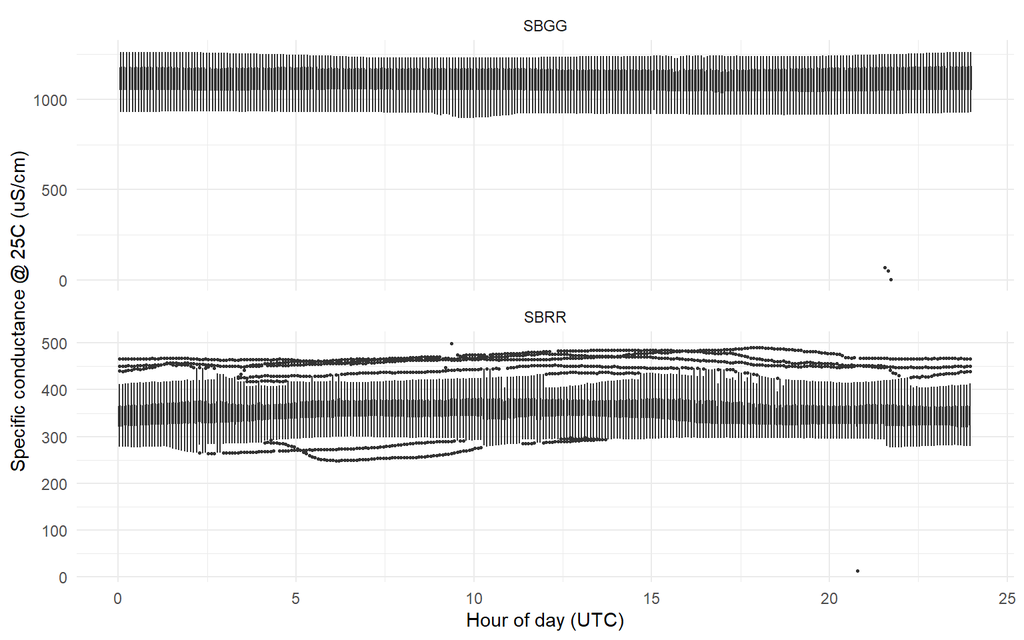

Hour-of-day distribution of specific conductance, by logger

```r
obs_clean |>
  mutate(hour = hour(timestamp) + minute(timestamp) / 60) |>
  ggplot(aes(x = hour, y = sc_25c, group = hour)) +
  geom_boxplot(outlier.size = 0.5) +
  facet_wrap(~external_station_code, ncol = 1, scales = "free_y") +
  labs(x = "Hour of day (UTC)", y = "Specific conductance @ 25C (uS/cm)") +
  theme_minimal()
```

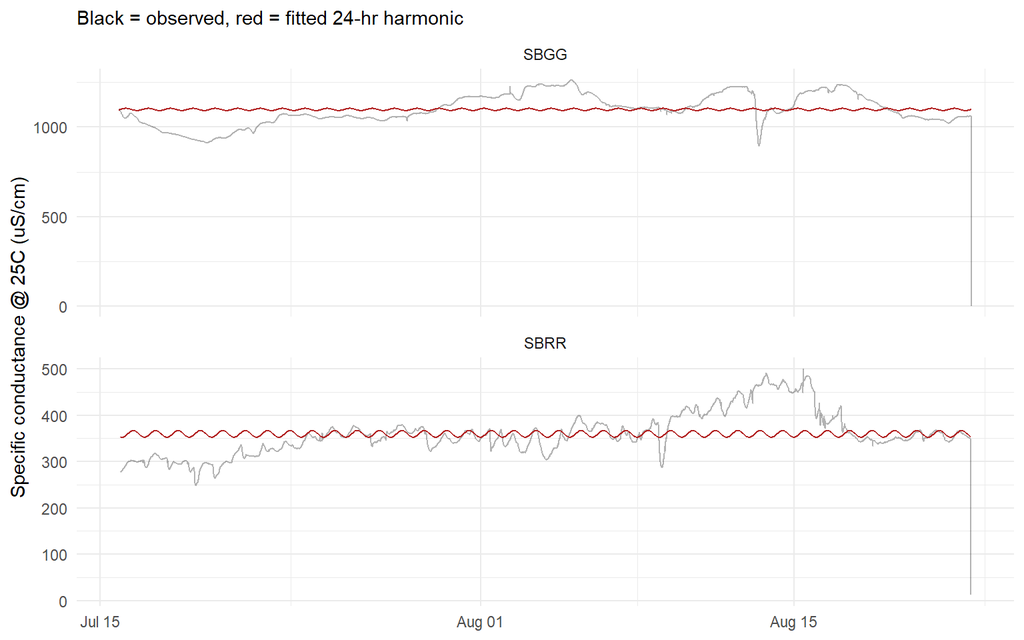

24-hour harmonic fit to specific conductance, by logger

```r
fit_harmonic <- function(df) {
  t_hours <- as.numeric(difftime(df$timestamp, min(df$timestamp), units = "hours"))
  # sc_25c(t) = alpha + b1*sin(2*pi*t/24) + b2*cos(2*pi*t/24) + e
  fit <- lm(sc_25c ~ sin(2 * pi * t_hours / 24) + cos(2 * pi * t_hours / 24), data = df)
  df$fitted <- predict(fit, newdata = df)
  attr(df, "amplitude") <- sqrt(sum(coef(fit)[-1]^2))
  df
}

harmonic_fits <- obs_clean |>
  filter(!is.na(sc_25c)) |>
  group_by(external_station_code) |>
  group_modify(~fit_harmonic(.x)) |>
  ungroup()

harmonic_fits |>
  ggplot(aes(x = timestamp)) +
  geom_line(aes(y = sc_25c), alpha = 0.3) +
  geom_line(aes(y = fitted), color = "firebrick") +
  facet_wrap(~external_station_code, ncol = 1, scales = "free_y") +
  labs(x = NULL, y = "Specific conductance @ 25C (uS/cm)",
       subtitle = "Black = observed, red = fitted 24-hr harmonic") +
  theme_minimal()
```

### 5.2 Autocorrelation structure

The autocorrelation function (ACF) at lag $k$,

$$\rho_k = \frac{\operatorname{Cov}\!\left(SC_{25}(t),\, SC_{25}(t-k)\right)}{\operatorname{Var}\!\left(SC_{25}(t)\right)},$$

quantifies how far into the future a current reading remains informative. We look at it twice: at the logger’s native ~5-minute cadence (short-lag persistence), and after resampling to each candidate chemistry-sampling interval (does a value from $k$ intervals ago still predict the current one at that coarser resolution?).

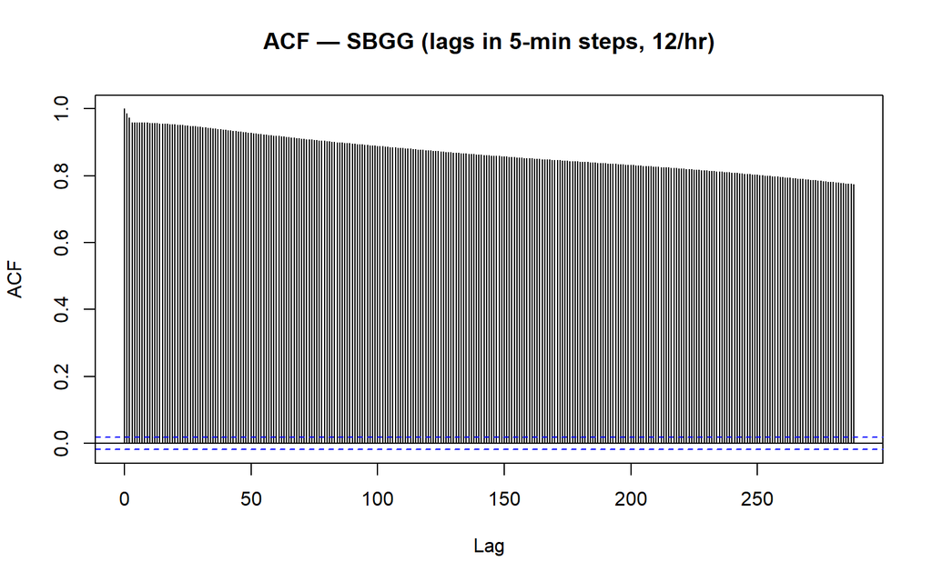

ACF at native (~5-min) cadence, by logger

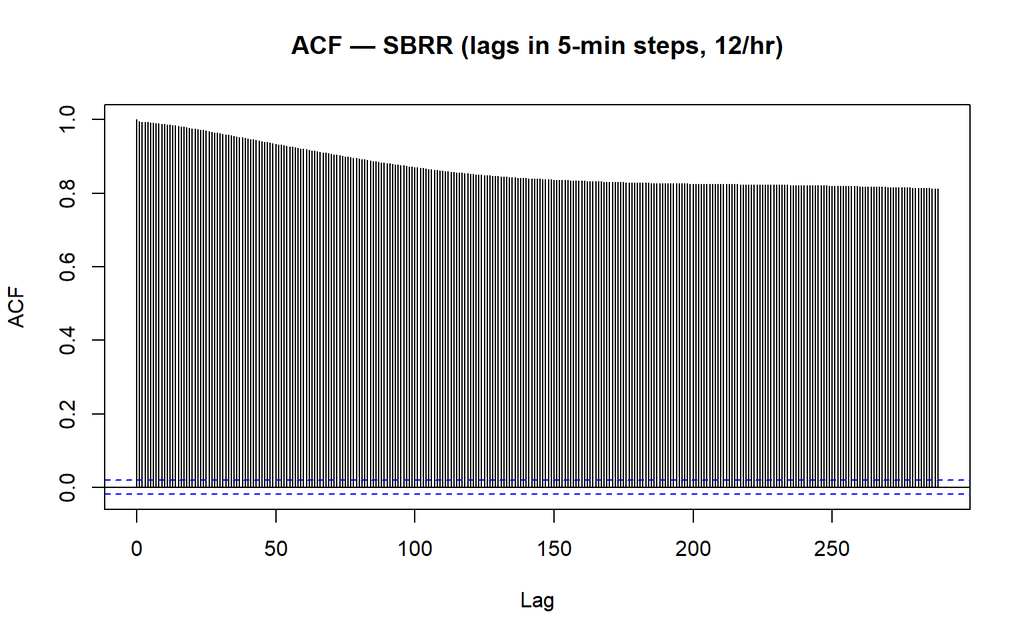

ACF at native (~5-min) cadence, by logger

```r
for (site in unique(obs_clean$external_station_code)) {
  x <- obs_clean |> filter(external_station_code == site) |> pull(sc_25c)
  x <- x[!is.na(x)]
  acf(x, lag.max = 24 * 12, main = paste("ACF —", site, "(lags in 5-min steps, 12/hr)"))
}
```

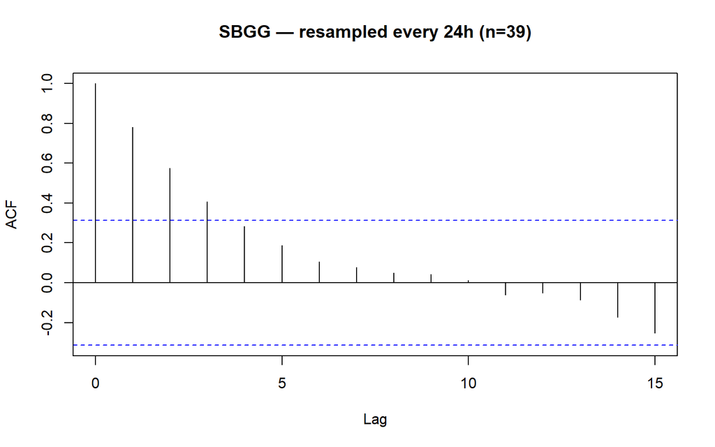

ACF resampled to candidate chemistry-sampling intervals

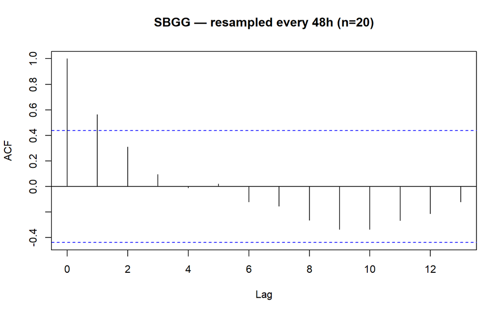

ACF resampled to candidate chemistry-sampling intervals

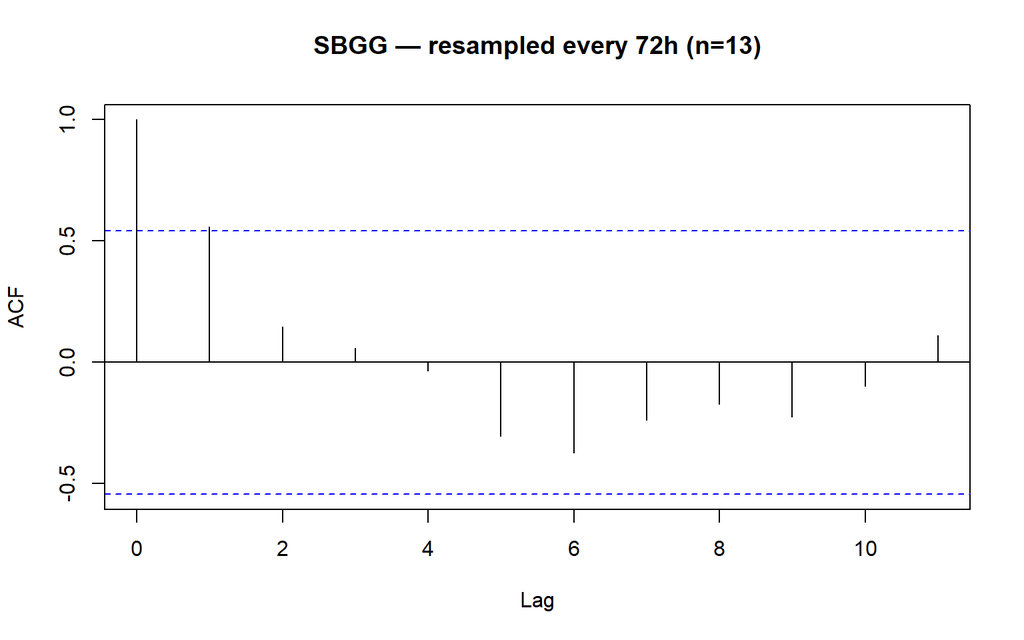

ACF resampled to candidate chemistry-sampling intervals

```
SBGG @ 168h: too few points yet (n=6) for a meaningful ACF
```

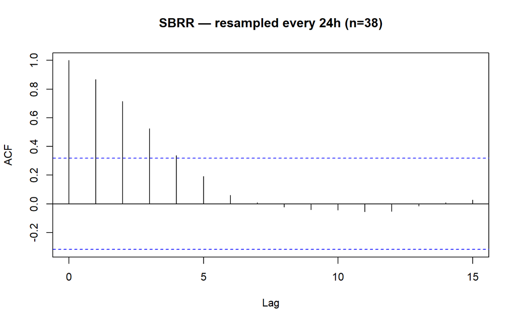

ACF resampled to candidate chemistry-sampling intervals

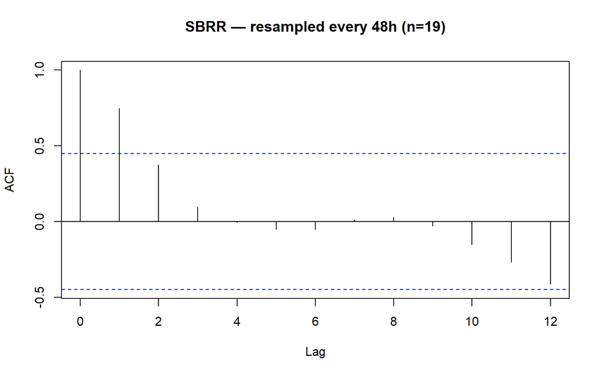

ACF resampled to candidate chemistry-sampling intervals

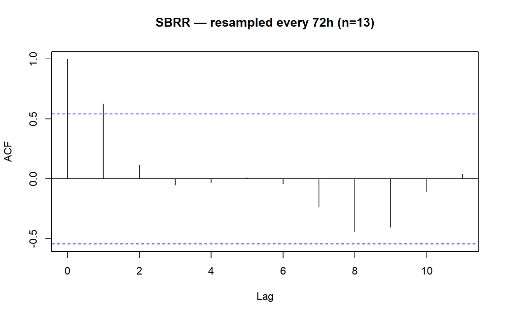

ACF resampled to candidate chemistry-sampling intervals

```
SBRR @ 168h: too few points yet (n=6) for a meaningful ACF
```

```r
resample_to <- function(df, interval_hours) {
  df |>
    mutate(bin = floor((as.numeric(timestamp) - as.numeric(min(timestamp))) / (interval_hours * 3600))) |>
    group_by(bin) |>
    summarise(sc_25c = mean(sc_25c, na.rm = TRUE), .groups = "drop")
}

candidate_intervals_hr <- c(24, 48, 72, 168)  # daily, 2-day, 3-day, weekly

for (site in unique(obs_clean$external_station_code)) {
  site_df <- obs_clean |> filter(external_station_code == site)
  for (h in candidate_intervals_hr) {
    rs <- resample_to(site_df, h)
    if (nrow(rs) > 10) {
      acf(rs$sc_25c, na.action = na.pass,
          main = paste0(site, " — resampled every ", h, "h (n=", nrow(rs), ")"))
    } else {
      message(site, " @ ", h, "h: too few points yet (n=", nrow(rs), ") for a meaningful ACF")
    }
  }
}
```

### 5.3 Spectral analysis

The periodogram estimates the spectral density $\hat{S}(f)$ across frequencies $f$, decomposing the series into the strength of cyclical components at each period $1/f$; a peak at 24 hours would confirm the diurnal signal seen above and reveal any other dominant periods (e.g. a semi-diurnal component, or longer synoptic-scale cycles as record length grows).

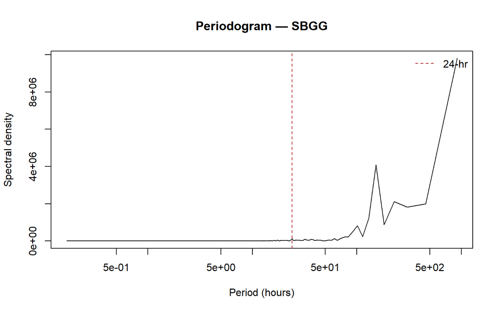

Periodogram (dominant frequencies), by logger

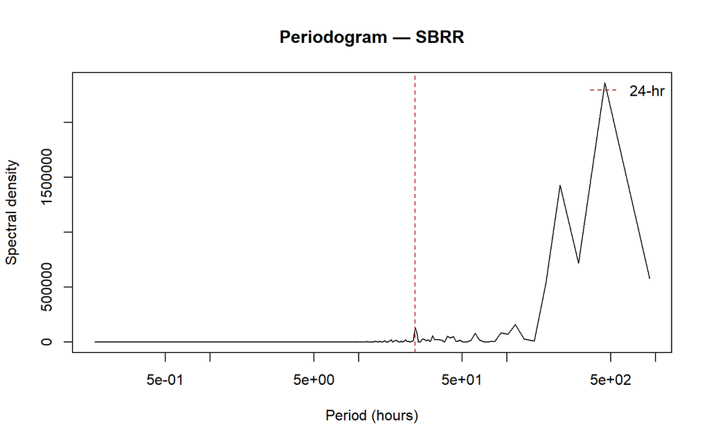

Periodogram (dominant frequencies), by logger

```r
for (site in unique(obs_clean$external_station_code)) {
  site_df <- obs_clean |> filter(external_station_code == site, !is.na(sc_25c)) |> arrange(timestamp)

  # Native cadence is nominally 5 min; a plain periodogram assumes even
  # spacing. Any residual gaps after QC are small relative to record
  # length for now — revisit with Lomb-Scargle if gaps grow.
  sp <- spec.pgram(site_df$sc_25c, taper = 0.1, log = "no", plot = FALSE)

  period_hours <- (1 / sp$freq) * (5 / 60)  # 5-min steps -> hours

  plot(period_hours, sp$spec, type = "l", log = "x",
       xlab = "Period (hours)", ylab = "Spectral density",
       main = paste("Periodogram —", site))
  abline(v = 24, col = "firebrick", lty = 2)
  legend("topright", legend = "24-hr", col = "firebrick", lty = 2, bty = "n")
}
```

### 5.4 Time-series decomposition

STL (Seasonal-Trend decomposition using Loess) additively decomposes the series into trend, (diurnal) seasonal, and remainder components,

$$SC_{25}(t) = T(t) + S(t) + R(t),$$

which separates a slow drift (e.g. seasonal baseflow change) from the fast diurnal cycle and from residual variability not explained by either — the remainder $R(t)$ is a useful working estimate of the “noise floor” that any chloride-prediction model built on $SC_{25}$ will ultimately be limited by.

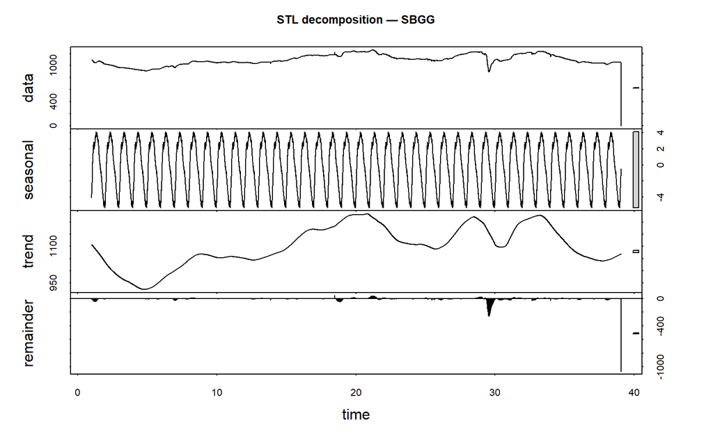

STL decomposition (trend / diurnal / remainder), by logger

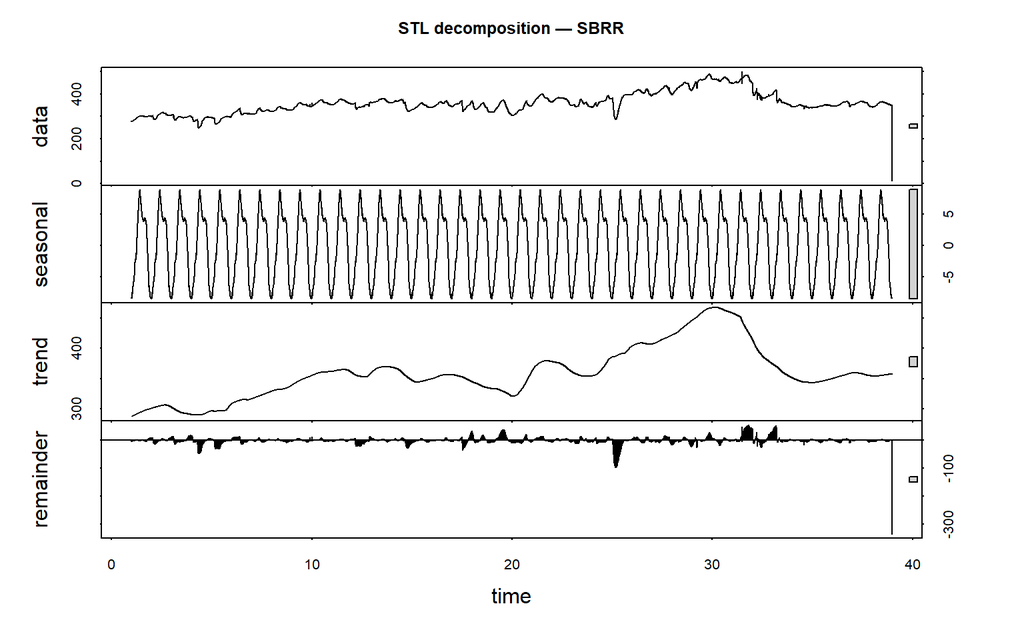

STL decomposition (trend / diurnal / remainder), by logger

```r
for (site in unique(obs_clean$external_station_code)) {
  site_df <- obs_clean |>
    filter(external_station_code == site) |>
    arrange(timestamp)

  # Regularize to 5-minute grid via linear interpolation across small gaps
  full_grid <- seq(min(site_df$timestamp), max(site_df$timestamp), by = "5 min")
  interp <- approx(site_df$timestamp, site_df$sc_25c, xout = full_grid)$y

  ts_obj <- ts(interp, frequency = 288)  # 288 = 5-min steps per day

  if (sum(!is.na(interp)) > 2 * 288) {
    decomp <- stl(zoo::na.approx(ts_obj, na.rm = FALSE), s.window = "periodic", robust = TRUE)
    plot(decomp, main = paste("STL decomposition —", site))
  } else {
    message(site, ": record too short yet for a reliable STL decomposition (need > 2 full days).")
  }
}
```

**Interpretation so far:** both loggers show a diurnal signal consistent with evapotranspiration/thermal-loading control on discharge and specific conductance, and native-cadence autocorrelation is strong out to several hours, as expected for a physically smooth process. Resampled (daily+) ACFs and the STL trend component will only become informative claims — rather than illustrations of the method — once several weeks to months of record have accumulated; treat any daily/weekly-scale conclusions drawn today as provisional.

## 6 From conductivity to chloride: predictive-model framework

Once paired chloride/conductance samples exist, the goal is a model $\hat{C}_{Cl} = f(SC_{25}, T, \text{season})$ that can be evaluated continuously from the logger record between chemistry samples. Three candidate model families are fit and compared (`scripts/analysis/sampling_frequency/03_chloride_models.R`), all using $SC_{25}$, stream temperature, and a first-harmonic seasonal term $\left(\sin\frac{2\pi \cdot doy}{365}, \cos\frac{2\pi \cdot doy}{365}\right)$ as predictors:

$$\begin{aligned}
\text{Linear:} \quad & C_{Cl} = \gamma_0 + \gamma_1 SC_{25} + \gamma_2 T + \gamma_3 \sin\theta_{doy} + \gamma_4 \cos\theta_{doy} + \varepsilon \\
\text{GAM:} \quad & C_{Cl} = \gamma_0 + g_1(SC_{25}) + g_2(T) + \gamma_3 \sin\theta_{doy} + \gamma_4 \cos\theta_{doy} + \varepsilon,\quad g_1, g_2 \text{ penalized splines} \\
\text{Random Forest:} \quad & C_{Cl} = h(SC_{25}, T, \sin\theta_{doy}, \cos\theta_{doy}) + \varepsilon,\quad h \text{ an ensemble of regression trees}
\end{aligned}$$

where $\theta_{doy} = 2\pi \cdot \text{day-of-year}/365$. The linear model is the interpretable baseline; the GAM allows nonlinear (but smooth, interpretable) response curves; the random forest allows arbitrary interaction structure at the cost of interpretability. All three are evaluated identically with **rolling-origin (blocked) cross-validation** — each fold trains only on data prior to the test window, which respects the temporal autocorrelation established in the ACF analysis above and avoids the optimistic bias that ordinary random k-fold CV would produce on an autocorrelated series.

`get_chloride_conductance_pairs()` currently returns 0 rows for the reason noted throughout this document (no temporal overlap between the 2026-05-01 chemistry samples and the 2026-07-15+ logger record). The block below therefore demonstrates the exact same functions against `simulate_synthetic_pairs()` — a synthetic dataset with a known, injected linear relationship — purely to confirm the modeling code path is correct end to end ahead of real data; **the numbers below are not a real conductivity-chloride relationship for Steamboat Creek.**

```r
source(file.path("scripts", "analysis", "sampling_frequency", "03_chloride_models.R"))

synthetic_pairs <- simulate_synthetic_pairs()
cv_results <- evaluate_chloride_models(synthetic_pairs, initial = 20, assess = 5, skip = 5)

cv_results |>
  group_by(model) |>
  summarise(mean_rmse = mean(rmse), mean_mae = mean(mae), n_folds = n())
```

```
# A tibble: 3 × 4
  model mean_rmse mean_mae n_folds
  <chr>     <dbl>    <dbl>   <int>
1 gam        1.25    1.15        8
2 lm         1.32    1.19        8
3 rf         1.06    0.947       8
```

## 7 Sampling-frequency design via Monte Carlo subsampling

Given a continuous reference chloride series (in practice, one of the fitted models above applied to the full-resolution conductivity record), the sampling-frequency question is answered by simulation (`scripts/analysis/sampling_frequency/04_monte_carlo_subsampling.R`): repeatedly subsample the reference at each candidate chemistry interval $\Delta \in \{1, 2, 3, 7, 14, 30\}$ days with a randomized phase offset, reconstruct the full series by linear interpolation between the subsampled points, and compare the reconstruction to the (known) reference. Concentration error uses

$$\text{RMSE}(\Delta) = \sqrt{\frac{1}{n}\sum_{i=1}^n \left(C_{Cl,i} - \hat{C}_{Cl,i}^{(\Delta)}\right)^2}, \qquad
\text{MAE}(\Delta) = \frac{1}{n}\sum_{i=1}^n \left|C_{Cl,i} - \hat{C}_{Cl,i}^{(\Delta)}\right|$$

and, when a paired discharge series $Q(t)$ is available, mass-flux error compares the trapezoidal-rule mass flux (Section 2’s $\Phi_{Cl}$, discretized) computed from the reconstruction against the true flux:

$$\Phi_{Cl}^{(\Delta)} \approx \sum_{i} \frac{\Delta t_i}{2}\Big(C_{Cl,i}Q_i + C_{Cl,i+1}Q_{i+1}\Big), \qquad
\text{FluxError\%}(\Delta) = 100 \times \frac{\Phi_{Cl}^{(\Delta)} - \Phi_{Cl}}{\Phi_{Cl}}$$

Repeating this many times per $\Delta$ (random draw of the sampling phase) and summarizing across draws (mean, 95th percentile) gives a distribution of error at each candidate frequency rather than a single, phase-dependent estimate. As with the previous section, this is demonstrated here on a synthetic reference series (`simulate_synthetic_reference()`) with known seasonal + diurnal structure, pending a real fitted reference series:

```r
source(file.path("scripts", "analysis", "sampling_frequency", "04_monte_carlo_subsampling.R"))

synthetic_reference <- simulate_synthetic_reference()
mc_draws <- monte_carlo_sampling_frequency(synthetic_reference, n_draws = 100)
mc_summary <- summarize_sampling_frequency(mc_draws)
mc_summary
```

```
   frequency_days n_draws rmse_mean  rmse_p95  mae_mean flux_pct_error_mean
1               1     100 0.6184689 0.7295317 0.5039541            2.512164
2               2     100 0.6078911 0.7159523 0.4935761            2.310075
3               3     100 0.6249030 0.7298311 0.5087032            2.630557
7               7     100 0.6156649 0.7436575 0.5008641            2.467088
14             14     100 0.6171644 0.7585577 0.5028358            2.475761
30             30     100 0.6183546 0.7639026 0.5041929            2.567440
   flux_pct_error_p95
1            4.019430
2            3.995132
3            4.192545
7            4.266793
14           4.349389
30           4.430792
```

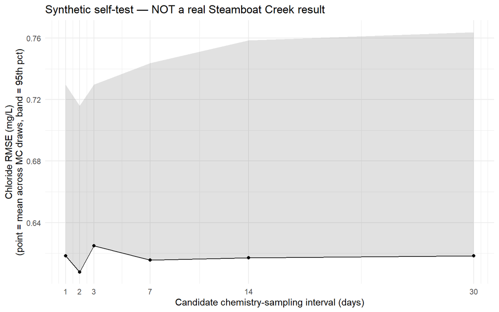

Synthetic-data illustration: chloride RMSE vs. candidate sampling interval

```r
ggplot(mc_summary, aes(x = frequency_days, y = rmse_mean)) +
  geom_ribbon(aes(ymin = rmse_mean, ymax = rmse_p95), alpha = 0.15) +
  geom_line() +
  geom_point() +
  scale_x_continuous(breaks = mc_summary$frequency_days) +
  labs(
    x = "Candidate chemistry-sampling interval (days)",
    y = "Chloride RMSE (mg/L)\n(point = mean across MC draws, band = 95th pct)",
    title = "Synthetic self-test — NOT a real Steamboat Creek result"
  ) +
  theme_minimal()
```

## 8 Turning an error curve into an actionable recommendation

`05_recommendation_report.R` intentionally requires an **explicit, user-supplied error threshold** — `rmse_threshold_mgL` and/or `flux_pct_threshold` — rather than defaulting to a convention. There is no statistically “correct” acceptable error here; it is a scientific decision about what change in chloride discharge would be meaningful to detect, which belongs with the PI, not with a default argument. Given a threshold, the recommended interval is the **coarsest** (largest $\Delta$) candidate whose mean error still satisfies it:

$$\Delta^{*} = \max\left\{\Delta : \overline{\text{RMSE}}(\Delta) \le \tau_{RMSE} \ \text{and} \ \overline{|\text{FluxError\%}|}(\Delta) \le \tau_{flux}\right\}$$

The block below applies this logic to the *synthetic* Monte Carlo summary above purely to illustrate the mechanics — the threshold value (1 mg/L) is an arbitrary illustrative choice, not a recommended one:

```r
source(file.path("scripts", "analysis", "sampling_frequency", "05_recommendation_report.R"))

# Illustrative threshold only — agree the real threshold with the PI
# before using this on real chloride/conductance data.
illustrative_threshold_mgL <- 1
recommend_sampling_frequency(mc_summary, rmse_threshold_mgL = illustrative_threshold_mgL)
```

```
   frequency_days n_draws rmse_mean  rmse_p95  mae_mean flux_pct_error_mean
30             30     100 0.6183546 0.7639026 0.5041929             2.56744
   flux_pct_error_p95
30           4.430792
```

When run for real, `build_recommendation_report()` additionally writes the summary table to `data/derived/sampling_frequency/` and the error-vs-frequency plot to `output/figures/sampling_frequency/`; it is not called here to avoid writing synthetic-data artifacts into those directories from this reference document.

## 9 Current status, gaps, and changelog

**Status of each step against real data:**

| Step | Real data available? | Blocking gap |
| --- | --- | --- |
| Conductivity temporal structure (§4) | Yes | None — record is short (~weeks) but real |
| SC temperature-compensation recalibration (§3) | No | 0 field-vs-logger pairs; need field conductivity checks collected *during* the logger deployment |
| Chloride prediction models (§5) | No | 0 chloride-vs-conductance pairs; existing Cl samples (2026-05-01) predate logger deployment (2026-07-15) by ~2.5 months |
| Monte Carlo sampling-frequency design (§6) | No | Depends on §5 producing a real fitted reference series |
| Final recommendation (§7) | No | Depends on §6, plus an explicit threshold agreed with the PI |

**Immediate next steps:**

1. Collect $\geq 5$ field conductivity checks at `SBRR`/`SBGG` while loggers are active, to unblock §3.
2. Collect chloride (and ideally paired discharge) samples that temporally overlap the active logger deployment window, to unblock §5–7.
3. Run `scripts/analysis/sampling_frequency/run_sampling_frequency.R`’s `run_sampling_frequency_pipeline(con)` for a one-call status check across all four steps above (idempotent – read-only unless `refit_models = TRUE` and real data support it). Once (2) is satisfied, also re-run this notebook — Sections 5–7 will automatically pull real pairs instead of falling through to synthetic self-tests, since `get_chloride_conductance_pairs()` and `get_calibration_pairs()` are the same functions used here and in the underlying scripts.
4. Agree an explicit $\tau_{RMSE}$ and/or $\tau_{flux}$ threshold with the PI before treating any output of §7 as an actual recommendation.

**Changelog:**

- 2026-09-05 — Added `scripts/analysis/sampling_frequency/run_sampling_frequency.R` as a single, idempotent entry point sequencing calibration -> chloride models -> Monte Carlo -> recommendation, mirroring `run_pipeline.R`’s style; each stage reports its status rather than requiring separate manual `source()`/function calls.
- 2026-09-05 — `SBRR`/`SBGG` logger role/serial assignment corrected (see provenance note in §2); confirmed the calibration join in §3 requires no code change as a result. Rewrote this notebook as the overarching reference document for the conductivity/chloride workstream, adding scientific motivation, explicit formulas alongside their implementing code, and worked (synthetic, clearly labeled) demonstrations of the chloride-model and Monte Carlo sections.